# MolB-RTI vs Skim-RTI vs BrB-RTI — calibrated ancestry-call comparison

Author

Fausto Rodríguez-Zapata

Published

June 26, 2026

**Repo:** sawers-rellan-labs/zealtiger

Calibrated cross-validation of ancestry source **#2 (SNP50K skim, ~0.4×)** against source **#5 (MolBreeding target sequencing, ~110×)** for the BZea NILs genotyped on both platforms. This is the **calibrated** successor to the frozen direct comparison (`docs/molbreeding_vs_skim.html`).

**What changed vs the frozen comparison.** The frozen notebook compared both platforms at a single borrowed **r=8**. Here each platform is called at its **truth-derived** rigidity — **Skim-RTI r=5, MolB-RTI r=2** (FP+FN argmin vs the simulated truth; methodology `docs/15-rigidity-and-scoring.md`), because the two coverage regimes have different physical resolution (`docs/14`). The **Null** is the **n=1500 BC2S3 simulation** (consensus map, no selection) — a modeled expectation, **not ground truth**: divergence from it is an observation. The per-platform calibration is done in `skim_sim_calibration.qmd` and `molb_sim_calibration.qmd`.

**BRB-seq layer (source #6), calibrated.** A third real-count platform — **BRB-seq 3′ bulk RNA-seq** — is layered in. GATK `CollectAllelicCounts` over the brbseq SNP sites gives `REF_COUNT`/`ALT_COUNT` with REF = B73 v5 / ALT = donor, so it is fed to RTIGER as real counts like the others, **without** the wideseq filter (RNA-seq covers only expressed regions and overlaps the wsfilt panel at too few markers to filter). Its rigidity is calibrated the same way: a benchmark in the **measured BRB-seq coverage regime** (λ̄ ≈ 2.8×, ~50 % structural missingness, fit from all 379 run_full samples) is swept and scored against truth, giving **r=5** (FP+FN argmin — the same coarse rigidity as the ~0.4× skim, reflecting BRB-seq’s low effective coverage). BRB-seq run_full sequenced plates PN1–PN4, so it overlaps the comparison only on the **8 PN4 samples** (7 teosinte NILs + the `PN4_SID326` B73 check); its sections below are restricted to those, while MolB-RTI-vs-Skim-RTI keeps all 16.

All sites are on the **wideseq-filtered** high-confidence panel (9,157 v5 SNPs, consistent REF=B73 / ALT=teosinte polarity). All 16 target-sequencing samples are kept (14 teosinte NILs + 2 B73-bulk checks); the 14 NILs are shared with the skim. Calls are RTIGER segments on B73 NAM v5 (`name, chr, start_bp, end_bp, state`; 0 = recurrent/B73, 1 = het, 2 = homozygous donor). Sample IDs are joined to target-sequencing wells via `data/molbreeding_45k_sample_map.tsv` (well_id → PN#_SID#); the calls already carry the PN#_SID# names.

**Naming (source × caller).** Call sets are labelled `Source-Caller`. Sources: **Skim** (SNP50K ~0.4× skim reads), **MolB** (MolBreeding target-capture ~110×), **BrB** (BRB-seq 3′ RNA-seq). Callers: **RTI** = RTIGER (per-marker HMM); **BIN** = BzeaSeq 1 Mb-bin GMM-HMM. So this notebook compares **MolB-RTI (r=2)**, **Skim-RTI (r=5)** and **BrB-RTI (r=5)**, and (in the Jaccard section) the **Skim-BIN** reference — `Skim-RTI` and `Skim-BIN` are the *same skim reads* through different filters + callers (50K-SNP RTIGER vs 27M→1 Mb-bin GMM-HMM). The n=1500 simulation is the **Null** and the breeding-scheme expectation is **p0**.

## Setup

```r
library(tidyverse); library(GenomicRanges); library(S4Vectors)
source("R/06_score_rtiger.R")
source("R/07_single_locus.R")
set.seed(params$seed)

mb      <- read_csv(params$mb_calls,   show_col_types = FALSE)   # target-seq wsfilt, r=2
skim    <- read_csv(params$skim_calls, show_col_types = FALSE)   # skim, per-taxon r=5
brb     <- read_csv(params$brb_calls,  show_col_types = FALSE)   # BRB-seq RNA, calibrated r=5
gmm     <- read_tsv(params$gmm_calls,  show_col_types = FALSE) %>%   # Skim-BIN (BzeaSeq 1Mb-bin GMM-HMM)
  transmute(name = sample, chr = as.integer(sub("chr", "", chrom)),
            start_bp = start, end_bp = end,
            state = c(REF = 0L, HET = 1L, ALT = 2L)[genotype])
smap    <- read_tsv(params$sample_map, show_col_types = FALSE)
sl      <- read_csv(params$seqlengths, show_col_types = FALSE)
nil_seg <- read_csv(params$nil_seg,    show_col_types = FALSE)   # NULL: introgression segments
nil_co  <- read_csv(params$nil_co,     show_col_types = FALSE)   # NULL: crossover counts

p0 <- single_locus_p0(n_bc = 2L, n_self = 3L)  # neutral breeding-scheme expectation

# common wideseq marker grid, from the filtered RTIGER count files
cf <- read_tsv(list.files(params$mb_counts, full.names = TRUE)[1],
               col_names = c("chr_label","bp","rb","rc","ab","ac"), show_col_types = FALSE)
grid    <- tibble(chr = as.integer(sub("chr","",cf$chr_label)), bp = cf$bp)
spacing <- sum(sl$len) / nrow(grid)

# samples present on both platforms (the 2 B73 checks have no skim NIL match)
samples <- intersect(unique(mb$name), unique(skim$name))
brb_samples <- intersect(unique(brb$name), unique(mb$name))   # BRB-seq overlaps PN4 only
cat(sprintf("MolB samples: %d (all kept) | shared with Skim: %d\n",
            n_distinct(mb$name), length(samples)))
```

```
MolB samples: 16 (all kept) | shared with Skim: 14
```

```r
cat(sprintf("BrB samples: %d | shared with MolB: %d | also with Skim: %d\n",
            n_distinct(brb$name), length(brb_samples),
            length(intersect(brb_samples, samples))))
```

```
BrB samples: 8 | shared with MolB: 8 | also with Skim: 7
```

```r
cat(sprintf("wideseq markers: %d (~%.0f kb spacing)\n", nrow(grid), spacing/1e3))
```

```
wideseq markers: 9157 (~233 kb spacing)
```

```r
cat(sprintf("resolution floor — Skim-RTI r=5 ≈ %.1f Mb | MolB-RTI r=2 ≈ %.1f Mb | BrB-RTI r=5 ≈ %.1f Mb\n",
            5*spacing/1e6, 2*spacing/1e6, 5*spacing/1e6))
```

```
resolution floor — Skim-RTI r=5 ≈ 1.2 Mb | MolB-RTI r=2 ≈ 0.5 Mb | BrB-RTI r=5 ≈ 1.2 Mb
```

```r
# donor blocks from a STATE-segment table (skim, target-seq): merge runs of state>0
donor_blocks <- function(seg) seg %>% arrange(name, chr, start_bp) %>% group_by(name, chr) %>%
  mutate(run = cumsum(c(TRUE, diff(state > 0) != 0)), donor = state > 0) %>% filter(donor) %>%
  group_by(name, chr, run) %>% summarise(size_mb = (max(end_bp)-min(start_bp))/1e6, .groups = "drop")
co_count <- function(seg) seg %>% arrange(name, chr, start_bp) %>% group_by(name, chr) %>%
  summarise(tr = sum(abs(diff(as.integer(state > 0)))), .groups = "drop") %>%
  group_by(name) %>% summarise(COs = sum(tr), .groups = "drop")
state_at <- function(df, s) {
  d <- df[df$name == s, ]
  d$state[findOverlaps(GRanges(grid$chr, IRanges(grid$bp, width = 1)),
                       GRanges(d$chr, IRanges(d$start_bp, d$end_bp)), select = "first")]
}
```

## Donor dosage & the B73-bulk control

Per-sample donor dosage (bp-weighted `state/2`). The neutral BC2S3 expectation ≈ 0.125; a flipped REF/ALT polarity would read ≈ 0.875. The two B73-bulk checks (`PN4_SID326`, `PN6_SID576`) should read ≈ 0 — a built-in validity test that needs no external truth.

```r
dosage <- function(seg) seg %>% mutate(len = end_bp - start_bp + 1) %>%
  group_by(name) %>% summarise(dosage = sum(len * state/2) / sum(len), .groups = "drop")
checks <- c("PN4_SID326", "PN6_SID576")
dose <- dosage(mb) %>% dplyr::rename(molb_r2 = dosage) %>%
  left_join(dosage(skim) %>% dplyr::rename(skim_r5 = dosage), by = "name") %>%
  left_join(dosage(brb)  %>% dplyr::rename(brbseq_r5 = dosage), by = "name") %>%
  mutate(is_B73_check = name %in% checks) %>% arrange(molb_r2)
dose
```

| name | molb_r2 | skim_r5 | brbseq_r5 | is_B73_check |
| --- | --- | --- | --- | --- |
| PN4_SID326 | 0.001250418 | NA | 0.07663445 | TRUE |
| PN6_SID575 | 0.010351386 | 0.009233704 | NA | FALSE |
| PN4_SID291 | 0.012811084 | 0.010560105 | 0.07290261 | FALSE |
| PN6_SID576 | 0.013469010 | NA | NA | TRUE |
| PN4_SID290 | 0.046467806 | 0.050927269 | 0.03280947 | FALSE |
| PN6_SID524 | 0.053139863 | 0.037340708 | NA | FALSE |
| PN4_SID293 | 0.063991776 | 0.052061134 | 0.05418640 | FALSE |
| PN4_SID320 | 0.067328160 | 0.069222155 | 0.08670370 | FALSE |
| PN6_SID509 | 0.075625275 | 0.063358759 | NA | FALSE |
| PN6_SID568 | 0.084225852 | 0.055281452 | NA | FALSE |

[output cut: 6 more lines]

```r
cat(sprintf("mean donor dosage — MolB-RTI (r=2) %.3f | Skim-RTI (r=5, shared) %.3f | BrB-RTI (r=5, shared) %.3f | neutral p0 %.3f\n",
            mean(dose$molb_r2[!dose$is_B73_check]),
            mean(dose$skim_r5[!is.na(dose$skim_r5)]),
            mean(dose$brbseq_r5[!is.na(dose$brbseq_r5)]), p0["ALT"] + 0.5*p0["Het"]))
```

```
mean donor dosage — MolB-RTI (r=2) 0.083 | Skim-RTI (r=5, shared) 0.062 | BrB-RTI (r=5, shared) 0.054 | neutral p0 0.125
```

```r
cat(sprintf("B73-bulk checks dosage (MolB-RTI): %s — expect ≈ 0\n",
            paste(sprintf("%s=%.3f", checks,
                          dose$molb_r2[match(checks, dose$name)]), collapse = ", ")))
```

```
B73-bulk checks dosage (MolB-RTI): PN4_SID326=0.001, PN6_SID576=0.013 — expect ≈ 0
```

**Read:** polarity is correct (dosage far below the ~0.875 of a flipped panel) and the B73-bulk checks read ≈ 0 — the built-in control passes. Both platforms read donor dosage **well below** the neutral 0.125, the donor-homozygote deficit the calibrated three-`f_i` analysis attributes to biology (`skim_sim_calibration.qmd`, `molb_sim_calibration.qmd`).

## State on the common grid

```r
paired <- map_dfr(samples, function(s) {
  a <- state_at(mb, s); k <- state_at(skim, s); ok <- !is.na(a) & !is.na(k)
  tibble(name = s, molb = a[ok], skim = k[ok])
})
```

## Confusion matrix — MolB-RTI vs Skim-RTI

Rows = MolB-RTI state (wideseq-filtered, r=2), cols = Skim-RTI (per-taxon r=5); cell = count (row %). Common wsfilt grid (9157 sites).

```r
cm <- table(molb = factor(paired$molb, 0:2), skim = factor(paired$skim, 0:2))
overall <- sum(diag(cm)) / sum(cm)
prop <- sweep(cm, 1, rowSums(cm), "/")
disp <- matrix(sprintf("%d (%.1f%%)", cm, 100*prop), nrow = 3,
               dimnames = list(`MolB-RTI \\ Skim-RTI` = c("0 recurrent","1 het","2 donor"),
                               c("0 recurrent","1 het","2 donor")))
knitr::kable(disp, align = "r",
             caption = sprintf("MolB-RTI (r=2, rows) vs Skim-RTI (r=5, cols): count (row %%). Overall concordance %.3f.", overall))
```

MolB-RTI (r=2, rows) vs Skim-RTI (r=5, cols): count (row %). Overall concordance 0.933.

|  | 0 recurrent | 1 het | 2 donor |
| --- | --- | --- | --- |
| 0 recurrent | 107127 (98.9%) | 581 (0.5%) | 663 (0.6%) |
| 1 het | 4026 (27.0%) | 9012 (60.4%) | 1871 (12.5%) |
| 2 donor | 1027 (22.6%) | 405 (8.9%) | 3117 (68.5%) |

```r
dp <- paired$molb %in% c(1, 2)
cat(sprintf("MolB-RTI donor-present markers: %d | Skim-RTI also donor-present: %.1f%%\n",
            sum(dp), 100*mean(paired$skim[dp] %in% c(1,2))))
```

```
MolB-RTI donor-present markers: 19458 | Skim-RTI also donor-present: 74.0%
```

```r
cat(sprintf("MolB-RTI homozygous-donor markers: %d | Skim-RTI also hom-donor: %.1f%%\n",
            sum(paired$molb == 2), 100*mean(paired$skim[paired$molb == 2] == 2)))
```

```
MolB-RTI homozygous-donor markers: 4549 | Skim-RTI also hom-donor: 68.5%
```

**Read:** marker-level concordance is high; the disagreements concentrate where MolB-RTI calls **het** and Skim-RTI calls **recurrent** — the ~0.4× skim’s het under-call, the direction the calibrated benchmarks predict.

## BrB-RTI rigidity calibration

RTIGER rigidity for BrB-RTI, swept on a benchmark in the measured BRB-seq coverage regime (λ̄ ≈ 2.8×, ~50 % structural missingness) and scored against simulated truth — same FP+FN criterion as the Skim-RTI / MolB-RTI calibrations. **r=5** is the argmin (and the donor F1 max).

```r
read_csv(params$brb_sweep, show_col_types = FALSE) %>%
  knitr::kable(digits = 3, caption = "BRB-seq rigidity sweep vs truth — err_FP_FN argmin selects r=5.")
```

BRB-seq rigidity sweep vs truth — err_FP_FN argmin selects r=5.

| r | err_FP_FN | dp_FP | dp_FN | dp_F1 | het_F1 | hd_F1 | co_bias |
| --- | --- | --- | --- | --- | --- | --- | --- |
| 2 | 58 | 10 | 48 | 0.978 | 0.966 | 0.985 | -0.53 |
| 3 | 55 | 7 | 48 | 0.979 | 0.964 | 0.985 | -0.59 |
| 5 | 54 | 3 | 51 | 0.980 | 0.964 | 0.986 | -0.69 |
| 8 | 62 | 2 | 60 | 0.977 | 0.954 | 0.982 | -0.82 |
| 10 | 70 | 4 | 66 | 0.973 | 0.942 | 0.977 | -0.91 |
| 15 | 90 | 7 | 83 | 0.966 | 0.924 | 0.971 | -1.09 |
| 20 | 105 | 10 | 95 | 0.960 | 0.904 | 0.963 | -1.31 |

## BrB-RTI cross-check (3′ RNA-seq, shared PN4 NILs)

BrB-RTI state on the common grid for the 8 shared samples, against MolB-RTI (reference) and Skim-RTI. Even at its calibrated r=5, RNA-seq covers only expressed regions at low depth, so treat BrB-RTI as a noisy qualitative read of donor presence, not a segment-resolution caller.

```r
paired_b <- map_dfr(brb_samples, function(s) {
  g <- state_at(mb, s); rr <- state_at(brb, s); k <- state_at(skim, s)
  ok <- !is.na(g) & !is.na(rr)
  tibble(name = s, molb = g[ok], brbseq = rr[ok],
         skim = if (s %in% samples) k[ok] else NA_integer_)
})
```

Rows = BrB-RTI state (r=5), cols = MolB-RTI (wsfilt, r=2); cell = count (row %).

```r
cm_bg <- table(brbseq = factor(paired_b$brbseq, 0:2), molb = factor(paired_b$molb, 0:2))
prop  <- sweep(cm_bg, 1, rowSums(cm_bg), "/")
disp  <- matrix(sprintf("%d (%.1f%%)", cm_bg, 100*prop), nrow = 3,
                dimnames = list(`BrB-RTI \\ MolB-RTI` = c("0 recurrent","1 het","2 donor"),
                                c("0 recurrent","1 het","2 donor")))
knitr::kable(disp, align = "r",
             caption = sprintf("BrB-RTI (r=5, rows) vs MolB-RTI (r=2, cols): count (row %%). Overall concordance %.3f.",
                               sum(diag(cm_bg))/sum(cm_bg)))
```

BrB-RTI (r=5, rows) vs MolB-RTI (r=2, cols): count (row %). Overall concordance 0.805.

|  | 0 recurrent | 1 het | 2 donor |
| --- | --- | --- | --- |
| 0 recurrent | 57994 (87.5%) | 5085 (7.7%) | 3215 (4.8%) |
| 1 het | 3602 (80.1%) | 567 (12.6%) | 329 (7.3%) |
| 2 donor | 1776 (83.3%) | 243 (11.4%) | 112 (5.3%) |

```r
dp <- paired_b$molb %in% c(1, 2)
cat(sprintf("MolB-RTI donor-present markers: %d | BrB-RTI also donor-present: %.1f%%\n",
            sum(dp), 100*mean(paired_b$brbseq[dp] %in% c(1,2))))
```

```
MolB-RTI donor-present markers: 9551 | BrB-RTI also donor-present: 13.1%
```

```r
cat(sprintf("BrB-RTI donor-present markers: %d | MolB-RTI also donor-present: %.1f%%\n",
            sum(paired_b$brbseq %in% c(1,2)),
            100*mean(paired_b$molb[paired_b$brbseq %in% c(1,2)] %in% c(1,2))))
```

```
BrB-RTI donor-present markers: 6629 | MolB-RTI also donor-present: 18.9%
```

Rows = BrB-RTI state, cols = Skim-RTI (r=5); restricted to samples on all three platforms.

```r
pb3   <- paired_b %>% filter(!is.na(skim))
cm_bk <- table(brbseq = factor(pb3$brbseq, 0:2), skim = factor(pb3$skim, 0:2))
prop  <- sweep(cm_bk, 1, rowSums(cm_bk), "/")
disp  <- matrix(sprintf("%d (%.1f%%)", cm_bk, 100*prop), nrow = 3,
                dimnames = list(`BrB-RTI \\ Skim-RTI` = c("0 recurrent","1 het","2 donor"),
                                c("0 recurrent","1 het","2 donor")))
knitr::kable(disp, align = "r",
             caption = sprintf("BrB-RTI (r=5, rows) vs Skim-RTI (r=5, cols): count (row %%). Overall concordance %.3f.",
                               sum(diag(cm_bk))/sum(cm_bk)))
```

BrB-RTI (r=5, rows) vs Skim-RTI (r=5, cols): count (row %). Overall concordance 0.824.

|  | 0 recurrent | 1 het | 2 donor |
| --- | --- | --- | --- |
| 0 recurrent | 51970 (89.7%) | 2602 (4.5%) | 3338 (5.8%) |
| 1 het | 3283 (83.0%) | 311 (7.9%) | 360 (9.1%) |
| 2 donor | 1512 (84.6%) | 123 (6.9%) | 152 (8.5%) |

**Read:** the headline concordance is carried by recurrent-state agreement; BrB-RTI recovers only a small fraction of the MolB-RTI donor markers and most of its own donor calls are unconfirmed — RNA-seq sparsity, not resolved at any rigidity.

## Segment scale & crossover count — MolB-RTI vs Skim-RTI vs Null

Null = the **n=1500 simulation** introgression segments (`nil_segments.csv`) and crossover counts (`nil_crossovers.csv`). For the null, “donor blocks” are the simulated introgression segments directly (no REF segments in that table).

```r
metrics_calls <- function(seg, lab, nsamp) {
  db <- donor_blocks(seg)
  tibble(source = lab,
         donor_blocks_per_sample = round(nrow(db)/nsamp, 1),
         median_donor_block_Mb   = round(median(db$size_mb), 2),
         median_COs              = median(co_count(seg)$COs))
}
mb_s   <- mb   %>% filter(name %in% samples)
skim_s <- skim %>% filter(name %in% samples)
brb_s  <- brb  %>% filter(name %in% brb_samples)
null_row <- tibble(source = "Null (n=1500 simulation)",
                   donor_blocks_per_sample = round(nrow(nil_seg)/n_distinct(nil_seg$nil_id), 1),
                   median_donor_block_Mb   = round(median(nil_seg$mb), 2),
                   median_COs              = median(nil_co$n_co))
bind_rows(
  metrics_calls(mb_s,   "MolB-RTI (r=2)",          length(samples)),
  metrics_calls(skim_s, "Skim-RTI (r=5)",          length(samples)),
  metrics_calls(brb_s,  "BrB-RTI (r=5, PN4 only)", length(brb_samples)),
  null_row) %>%
  knitr::kable()
```

| source | donor_blocks_per_sample | median_donor_block_Mb | median_COs |
| --- | --- | --- | --- |
| MolB-RTI (r=2) | 14.0 | 5.68 | 22 |
| Skim-RTI (r=5) | 5.5 | 11.51 | 8 |
| BrB-RTI (r=5, PN4 only) | 21.9 | 0.02 | 43 |
| Null (n=1500 simulation) | 10.3 | 10.74 | 33 |

**Read:** MolB-RTI resolves more, smaller donor blocks and more crossovers than the coverage-limited Skim-RTI — the high-coverage platform recovers fine structure the skim merges. Both call **fewer** crossovers than the Null expects (the caller’s segment-merging floor vs the modeled recombination rate); the Null is an expectation, not truth.

## Introgression-size distribution

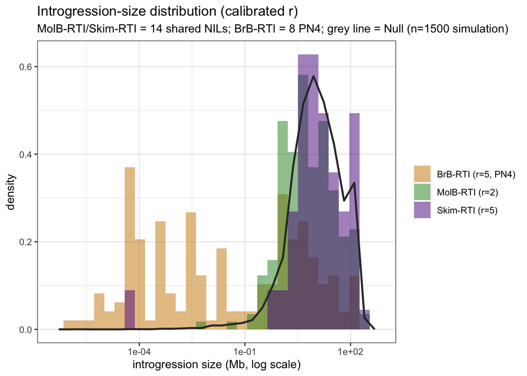

```r
molb_b <- donor_blocks(mb_s)   %>% mutate(src = "MolB-RTI (r=2)")
skim_b <- donor_blocks(skim_s) %>% mutate(src = "Skim-RTI (r=5)")
brb_b  <- donor_blocks(brb_s)  %>% mutate(src = "BrB-RTI (r=5, PN4)")
null_b <- nil_seg %>% transmute(size_mb = mb)
ggplot(bind_rows(molb_b, skim_b, brb_b), aes(x = size_mb, fill = src)) +
  geom_histogram(aes(y = after_stat(density)), position = "identity", alpha = 0.5, bins = 30) +
  geom_freqpoly(data = null_b, aes(x = size_mb, y = after_stat(density)),
                bins = 30, colour = "grey20", linewidth = 0.9, inherit.aes = FALSE) +
  scale_fill_manual(values = c("MolB-RTI (r=2)" = "forestgreen", "Skim-RTI (r=5)" = "purple4",
                               "BrB-RTI (r=5, PN4)" = "orange3")) +
  scale_x_log10() +
  labs(x = "introgression size (Mb, log scale)", y = "density", fill = NULL,
       title = "Introgression-size distribution (calibrated r)",
       subtitle = "MolB-RTI/Skim-RTI = 14 shared NILs; BrB-RTI = 8 PN4; grey line = Null (n=1500 simulation)") +
  theme_bw()
```

## Donor-call composition — het vs homozygous donor

Per-sample het and homozygous-donor **fraction** of the common grid, by platform. The top reference row is the **neutral breeding-scheme p₀** (Het 0.03125, hom-donor 0.10938; `single_locus_p0(2,3)`) — the expectation under no selection.

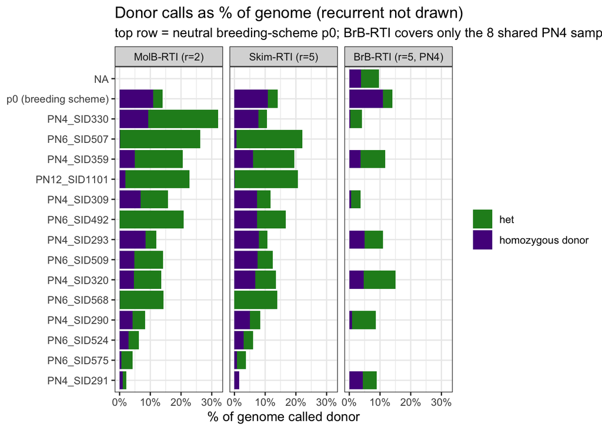

```r
# per-name marker total differs by platform (MolB-RTI/Skim-RTI on the full grid,
# BrB-RTI on its shared subset), so each platform carries its own denominator
tot_gs <- count(paired,   name, name = "tot")
tot_b  <- count(paired_b, name, name = "tot")
comp <- bind_rows(
  paired   %>% transmute(name, platform = "MolB-RTI (r=2)", state = molb) %>%
    filter(state %in% c(1,2)) %>% count(name, platform, state) %>% left_join(tot_gs, by = "name"),
  paired   %>% transmute(name, platform = "Skim-RTI (r=5)",     state = skim) %>%
    filter(state %in% c(1,2)) %>% count(name, platform, state) %>% left_join(tot_gs, by = "name"),
  paired_b %>% transmute(name, platform = "BrB-RTI (r=5, PN4)", state = brbseq) %>%
    filter(state %in% c(1,2)) %>% count(name, platform, state) %>% left_join(tot_b, by = "name")) %>%
  mutate(pct = n/tot, state = factor(state, c(1,2), c("het","homozygous donor")))

platforms <- c("MolB-RTI (r=2)", "Skim-RTI (r=5)", "BrB-RTI (r=5, PN4)")
# p0 reference row, drawn at the top of every facet
p0_ref <- expand_grid(platform = platforms,
                      tibble(state = factor(c("het","homozygous donor"),
                                            c("het","homozygous donor")),
                             pct = c(p0["Het"], p0["ALT"]))) %>%
  mutate(name = "p0 (breeding scheme)")

ord <- paired %>% group_by(name) %>% summarise(d = mean(molb)/2) %>% arrange(d) %>% pull(name)
comp_all <- bind_rows(comp, p0_ref) %>%
  mutate(name = factor(name, levels = c(ord, "p0 (breeding scheme)")),
         platform = factor(platform, platforms))
ggplot(comp_all, aes(y = name, x = pct, fill = state)) +
  geom_col(position = "stack") + facet_wrap(~ platform) +
  scale_fill_manual(values = c("het" = "forestgreen", "homozygous donor" = "purple4")) +
  scale_x_continuous(labels = scales::percent) +
  labs(x = "% of genome called donor", y = NULL, fill = NULL,
       title = "Donor calls as % of genome (recurrent not drawn)",
       subtitle = "top row = neutral breeding-scheme p0; BrB-RTI covers only the 8 shared PN4 samples") +
  theme_bw()
```

**Read:** nearly every NIL sits **above** the neutral p₀ on het and **below** it on homozygous donor — the heterozygote-excess / donor-homozygote-deficit signal, visible on both platforms and **stronger on MolB-RTI** (which resolves het Skim-RTI under-calls). The calibrated three-`f_i` decomposition (`skim_sim_calibration.qmd`, `molb_sim_calibration.qmd`) attributes this to real biology, not method bias.

## Chromosome painting — all 16 lines, MolB-RTI vs Skim-RTI vs BrB-RTI

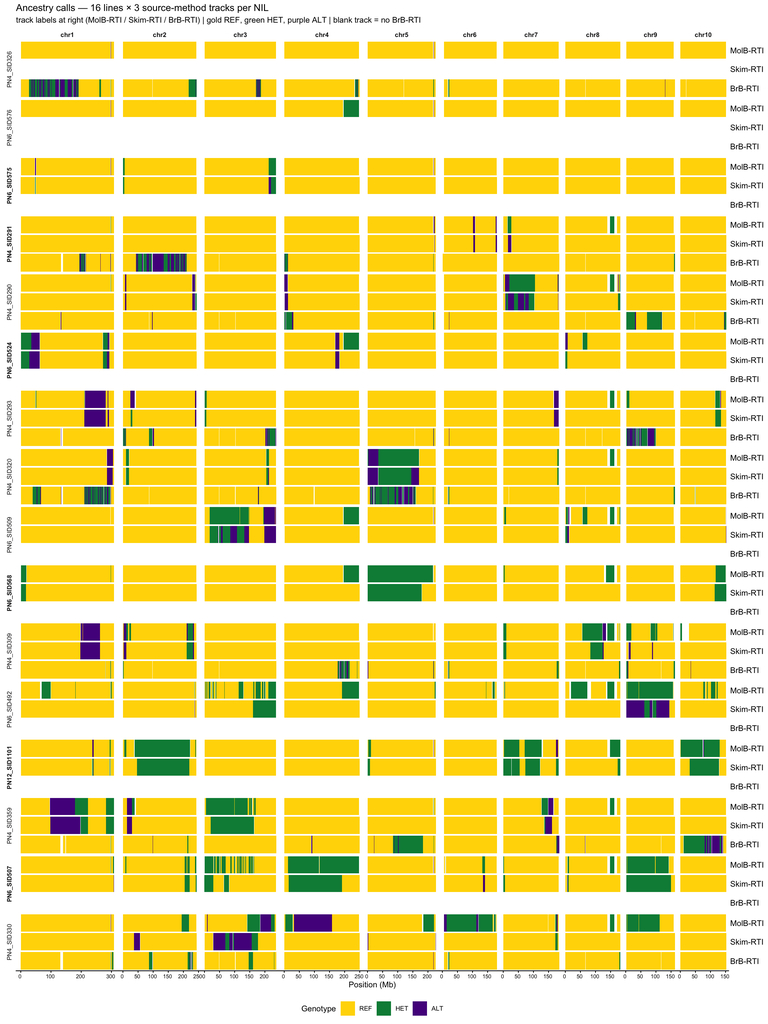

```r
pal <- c(REF = "gold", HET = "springgreen4", ALT = "purple4")
# B73-bulk checks pinned at the top, then NILs by increasing target-seq introgression
ord <- c(checks, dose %>% filter(!name %in% checks) %>% arrange(molb_r2) %>% pull(name))

# LowQuality samples (sample_map QC flag) get a bold facet-strip label (markdown)
lowq <- smap$sample_id[smap$quality == "LowQuality" & !is.na(smap$quality)]
name_lab <- function(x) if_else(x %in% lowq, paste0("**", x, "**"), x)

paint <- bind_rows(
  mb   %>% transmute(name, chr, start_bp, end_bp, state, method = "MolB-RTI (r=2)"),
  skim %>% filter(name %in% unique(mb$name)) %>%
           transmute(name, chr, start_bp, end_bp, state, method = "Skim-RTI (r=5)"),
  brb  %>% transmute(name, chr, start_bp, end_bp, state, method = "BrB-RTI (r=5)")) %>%
  mutate(state  = factor(state, 0:2, c("REF", "HET", "ALT")),
         chr    = factor(chr, levels = 1:10, labels = paste0("chr", 1:10)),
         name   = factor(name_lab(name), levels = name_lab(ord)),
         method = factor(method, c("MolB-RTI (r=2)","Skim-RTI (r=5)","BrB-RTI (r=5)")),
         # three stacked lanes per sample: MolB-RTI top, Skim-RTI middle, BrB-RTI bottom
         ylo = case_when(method == "MolB-RTI (r=2)" ~ 0.69, method == "Skim-RTI (r=5)" ~ 0.35, TRUE ~ 0.00),
         yhi = case_when(method == "MolB-RTI (r=2)" ~ 1.00, method == "Skim-RTI (r=5)" ~ 0.66, TRUE ~ 0.32))

# per-track source-method label, placed at each lane's y-midpoint (bottom -> top)
lane_mid <- c(0.16, 0.505, 0.845)
lane_lab <- c("BrB-RTI", "Skim-RTI", "MolB-RTI")
ggplot(paint, aes(xmin = start_bp/1e6, xmax = end_bp/1e6,
                  ymin = ylo, ymax = yhi, fill = state)) +
  geom_rect() +
  facet_grid(name ~ chr, scales = "free_x", space = "free_x", switch = "y") +
  scale_fill_manual(values = pal, drop = FALSE) +
  scale_x_continuous(labels = scales::unit_format(unit = "", scale = 1)) +
  scale_y_continuous(breaks = lane_mid, labels = lane_lab,
                     expand = expansion(mult = 0.02), position = "right") +
  labs(title = "Ancestry calls — 16 lines × 3 source-method tracks per NIL",
       subtitle = "track labels at right (MolB-RTI / Skim-RTI / BrB-RTI) | gold REF, green HET, purple ALT | blank track = no BrB-RTI",
       x = "Position (Mb)", fill = "Genotype") +
  ggpubr::theme_classic2(base_size = 9) +
  theme(legend.position = "bottom",
        strip.background = element_blank(),
        strip.text.x = element_text(face = "bold"),
        # NIL name rotated 90° CCW (vertical) at the far left of each row group
        strip.text.y.left = ggtext::element_markdown(angle = 90, hjust = 0.5, size = 7),
        panel.spacing.x = unit(0.05, "lines"),
        panel.spacing.y = unit(0.05, "lines"),
        # per-track source-method label, horizontal, to the RIGHT of each genome track
        axis.text.y.right = element_text(size = 9), axis.ticks.y = element_blank(),
        axis.title.y = element_blank(), axis.line.y = element_blank(),
        axis.text.x = element_text(size = 6))
```

**Read:** wherever the MolB-RTI and Skim-RTI lanes disagree it is almost always MolB-RTI calling het/donor where Skim-RTI calls recurrent — the coverage-limited skim collapses small heterozygous tracts to background. The B73-bulk checks are near-all-gold, confirming polarity and the caller’s specificity on a known-recurrent genome. The BrB-RTI bottom lane (8 PN4 lines) is sparse and speckled — scattered short blocks rather than the contiguous tracts MolB-RTI resolves, picking up some of the largest donor regions but missing most.

> A separate notebook, `gmm_hmm_caller_comparison.qmd`, brings in the BzeaSeq 1 Mb-bin GMM-HMM caller (**Skim-BIN**) and compares all three callers (MolB-RTI (r=2), Skim-RTI (r=5), Skim-BIN) on these same 16 lines.

## Jaccard agreement vs Skim-BIN calls

Per-sample **Jaccard index** of donor-present markers (state ∈ {het, donor}) on the common grid, each method against the **Skim-BIN** (BzeaSeq 1 Mb-bin GMM-HMM on the skim reads) calls as the reference: `J = |donor_method ∩ donor_BIN| / |donor_method ∪ donor_BIN|`, over grid markers where both call sets define a state. `1` = identical introgression footprint, `0` = disjoint. **Restricted to samples scored by all three methods** — the shared PN4 NILs (BrB-RTI is PN4-only, and Skim-RTI has no B73 checks), so the three columns are directly comparable on the same rows.

```r
donor_set <- function(df, s) {                 # grid indices called donor by df for sample s
  st <- state_at(df, s); which(!is.na(st) & st > 0)
}
jaccard_vs_gmm <- function(df, s) {
  if (!s %in% df$name || !s %in% gmm$name) return(NA_real_)
  a <- donor_set(df, s); b <- donor_set(gmm, s)
  u <- length(union(a, b)); if (u == 0) return(NA_real_)
  length(intersect(a, b)) / u
}
# row order: B73 checks first, then NILs by increasing target-seq donor dosage
jac_ord <- c(checks, dose %>% filter(!name %in% checks) %>% arrange(molb_r2) %>% pull(name))
jac <- tibble(sample = jac_ord) %>%
  mutate(`MolB-RTI` = map_dbl(sample, ~ jaccard_vs_gmm(mb,   .x)),
         `Skim-RTI` = map_dbl(sample, ~ jaccard_vs_gmm(skim, .x)),
         `BrB-RTI`  = map_dbl(sample, ~ jaccard_vs_gmm(brb,  .x))) %>%
  # keep only samples with a Jaccard for all three methods (the shared PN4 NILs)
  filter(if_all(c(`MolB-RTI`, `Skim-RTI`, `BrB-RTI`), ~ !is.na(.x)))
jac %>%
  knitr::kable(digits = 3, caption = "Jaccard agreement of donor-present markers vs Skim-BIN calls (per sample × method), restricted to samples scored by all three methods.")
```

Jaccard agreement of donor-present markers vs Skim-BIN calls (per sample × method), restricted to samples scored by all three methods.

| sample | MolB-RTI | Skim-RTI | BrB-RTI |
| --- | --- | --- | --- |
| PN4_SID291 | 0.638 | 0.747 | 0.000 |
| PN4_SID290 | 0.821 | 0.776 | 0.057 |
| PN4_SID293 | 0.862 | 0.957 | 0.001 |
| PN4_SID320 | 0.958 | 0.965 | 0.403 |
| PN4_SID309 | 0.760 | 0.900 | 0.049 |
| PN4_SID359 | 0.515 | 0.519 | 0.011 |
| PN4_SID330 | 0.103 | 0.955 | 0.079 |

```r
jac %>% summarise(across(c(`MolB-RTI`, `Skim-RTI`, `BrB-RTI`),
                         ~ mean(.x, na.rm = TRUE))) %>%
  knitr::kable(digits = 3, caption = "Mean Jaccard vs Skim-BIN (NA-dropped).")
```

Mean Jaccard vs Skim-BIN (NA-dropped).

| MolB-RTI | Skim-RTI | BrB-RTI |
| --- | --- | --- |
| 0.665 | 0.831 | 0.086 |

**Read:** **Skim-RTI** tracks Skim-BIN best — same ~0.4× skim reads, two different callers, so the donor footprints largely coincide. **MolB-RTI** agrees less by this index even though it is the higher-coverage truth: it resolves het tracts Skim-BIN misses, inflating the union. **BrB-RTI** is lowest — its sparse, fragmented donor calls overlap the Skim-BIN footprint only partially.